# MATHS1004 Mathematics for Data Science I

In this practical we will see how to work with basic mathematical functions in Python

## Basic Arithmetic with Python:

We can carry out basic arithmetic operations with python. Lets start with a couple of variables.

```python
x = 3
y = 4
```

We can add and substract with + and -

```python
x+y
```

```
7
```

```python
x-y
```

```
-1
```

We can multiply and divide with * and /

```python
x*y
```

```
12
```

```python
x/y
```

```
0.75
```

Hopefully no surprises so far, but there is something new we have encountered here which is not obvious. Python has different types of numbers. Until we did $x/y$ all of our numbers were integers, but the answer to $x/y$ is a decimal so it is treated differently by Python, it is called a floating point number. The function type will return the type of the number (or in fact the type of any object in Python).

```python
type(1)
```

```
int
```

```python
type(0.75)
```

```
float
```

In general floating point numbers are approximations, for example consider $y/x = 4/3$:

```python
y/x
```

```
1.3333333333333333
```

Floating point numbers are also used to deal with very large and very small numbers for which scientific notation is used. The letter e followed by a number indicates 10 to that power, for example $1000 = 1e03$ and $0.024 = 2.4e-02$.

```python
1/123456789
```

```
8.100000073710001e-09
```

```python
123456789*123456789
```

```
15241578750190521
```

```python
123456789*123456789.0
```

```
1.524157875019052e+16
```

Note the difference in the previous two answers. In the first the product of two integers is an integer, but in the second the decimal place makes it into a floating point number, so the result is given as a floating point number using scientific notation.

In general division / results in a floating point number, even if the result could be represented as an integer

```python
type(4/2)
```

```
float
```

There is another type of division represented by // which always produces an integer

```python
type(4//2)
```

```
int
```

What happens if the result of the division is not an integer? Try it yourself and see what you can deduce

```python
5.5/3
```

```
1.8333333333333333
```

One final arithmetic operation is to raise a number to a power, for this we use ** for example 3** 2 $= 3^2$

```python
3**2
```

```
9
```

You can try out your own calculations below to test out these various operations

```python
4 + 5**2
```

```
29
```

```python
5**7
```

```
78125
```

Now lets test out what you have learnt. Do the following calculation: $\frac{(123+987)^2 - 1000.1}{1.234\times 10^5}$

```python
z=(123+987)**2
z=z-1000.1
z/(1.234*10**5)
```

```
9.976498379254457
```

Your answer should be 9.976498379254457

## The math module

Python has many modules which are used to access specialised operations. Before these can be used they must be imported. Many basic mathematical functions are contained in the math module, these are accessed with math.*function* where *function* is the name of the specific function we want to use, for example math.sqrt will calculate a square root. Lets start by trying it without importing, we are all bound to do this accidentally at some point so it will be good to recognise what it looks like

```python
math.sqrt(4)
```

```
---------------------------------------------------------------------------
NameError                                 Traceback (most recent call last)
<ipython-input-41-3ffc6eec8d9e> in <module>
----> 1 math.sqrt(4)

NameError: name 'math' is not defined
```

We've received an error message because math is not recognised it, so we will import it and then try again

```python
import math
math.sqrt(4)
```

```
2.0
```

Now that we have imported it we can access it without having to import again for the rest of our session, try calculating another square root below without the import math command

```python
math.sqrt(9)
```

```
3.0
```

The math module also allow access to some important constants, for example $\pi$

```python
math.pi
```

```
3.141592653589793
```

You can see all of the functions provided by the math module here https://docs.python.org/3/library/math.html Some of them will be familiar to you and some not, we will introduce the ones we need as we encounter them throughout the course. See if you can find out how to do the following calculation: $\sqrt{\ln(5)+ \sqrt[3]{2}}$

```python
w=1/3
w=2**w
w=w+math.log1p(5-1)
math.sqrt(w)
```

```
1.6939182277574598
```

Your answer should be 1.6939182277574598

## Defining functions

```python
def f(x):
    return (x**2+1)/(x-7)
```

Note a couple of points of syntax, we need a semicolon : after the def command, and we must have the next line indented - Jupyter does this automatically. Included in the definition is a variable the function depends on, x, and Python is told what comes back after a function call with the keyword "return".

Now we should be able to call values of our function.

```python
f(1.35)
```

```
-0.4995575221238938
```

```python
f(10)
```

```
33.666666666666664
```

```python
f(7) #The denominator is 0 when x=7
```

```
---------------------------------------------------------------------------
ZeroDivisionError                         Traceback (most recent call last)
<ipython-input-49-6bc3e6592621> in <module>
----> 1 f(7) #The denominator is 0 when x=7

<ipython-input-46-ea1e3c5f31d9> in f(x)
      1 def f(x):
----> 2     return (x**2+1)/(x-7)

ZeroDivisionError: division by zero
```

If we look at the function we can see why the last one doesn't work, but it is good to be familiar with what errors look like when they occur.

Python already has lots of mathematical functions built in, but remember that we need to import a package to use them. We will encounter a few different mathematical packages, including math which we have already seen. This time we will mostly use pylab, which can also be used to define common functions. Using this we can define a function $g(x) = e^{f(x)}$, where $f(x)$ is the function defined above. Remember that we have to import a package before using it.

```python
import pylab
def g(x):
    return pylab.exp(f(x))
g(1)
```

```
0.7165313105737893
```

We have also seen some piecewise functions, we can define these in python using if, elif and else commands. For example, suppose $p(x) = \begin{cases} 0 \text{ if } x < 1 \\ x \text{ if } 1 \leq x \leq 2 \\ x^2 +3 \text{ if } x > 2 \end{cases}$

```python
def p(x):
    if x < 1:
        return 0
    elif 1 <= x <= 2:
        return x
    else:
        return x**2 + 3
```

Now try evaluating some values of $p$, choose three values which test out the three different rules

```python
p(-1)
```

```
0
```

```python
p(1.5)
```

```
1.5
```

```python
p(3)
```

```
12
```

Can you define the absolute value function $|x|$? Try it below (Hint: maybe give it the name $A(x)$)

```python
def A(x):
    if x<0:
        return x*-1
    else:
        return x
```

Actually, we don't need to define it from scratch because it's already defined:

```python
abs(-2)
```

```
2
```

```python
A(-999)
```

```
999
```

## Graphs

Last time we made a histogram with pylot. We can also use this to plot the graphs of functions.

Here is the link to the pyplot tutorial again: https://matplotlib.org/tutorials/introductory/pyplot.html

Try plotting the graph of $f(x)$ between $1$ and $4$ by taking $15$ samples.

Hint: You will need to `import numpy as np` and use `np.arange` as in the tutorial.

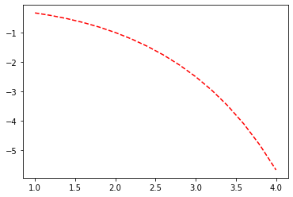

```python
import numpy as np
import matplotlib.pyplot as plt
y=3/15
t1=np.arange(1.0, 4.1, y)
plt.plot(t1,f(t1),'r--')
plt.show()
```

[output not shown]

[figure not shown]

```python
t2=np.arange(1.0, 8.1, 0.0175)
plt.plot(t2, f(t2), 'r--')
plt.show()
```

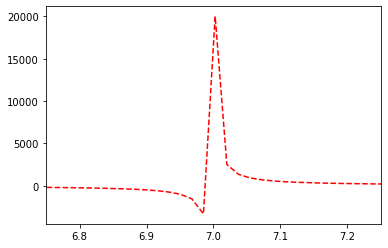

```python
t3=np.arange(1.0, 8.1, 0.0175)
plt.plot(t3, f(t3), 'r--')
plt.xlim([6.75,7.25])
plt.show()
```

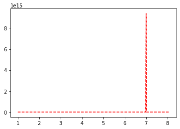

```python
t4=np.arange(1.0, 8.1,0.02)
plt.plot(t4, f(t4), 'r--')
plt.show()
```

What happens if we try to plot it between $1$ and $8$ (say with sample size 0.0175)? (What about sample size 0.02?)

Notice that the output is pretty sensitive to the sample size and also has some weird vertical-looking lines.

What is going on here?